# NPI Specialty Clustering with PCA and K-Means

## kmeans clustering

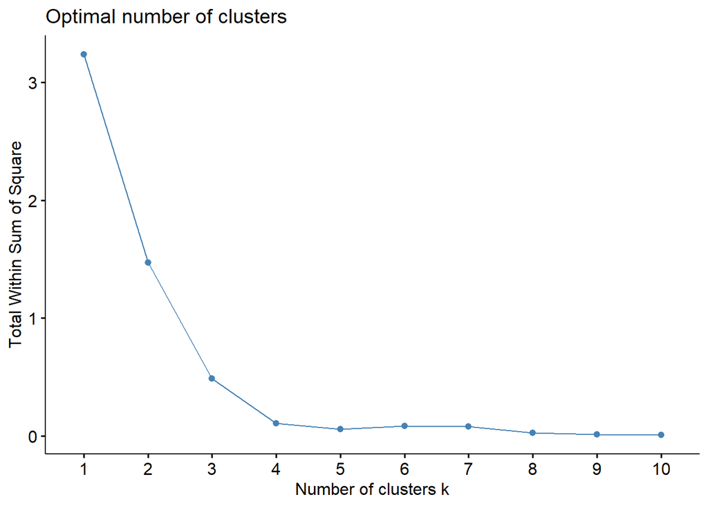

```r
#Using the elbow method to find ideal # of clusters
fviz_nbclust(pc_dt[ , 2:3], kmeans, method = "wss")
```

insight: We see an elbow bend after 4 clusters

```r
#make this example reproducible
set.seed(1)

#perform k-means clustering with k = 4 clusters
km <- kmeans(pc_dt[ , 2:3], centers = 4, nstart = 25)

#view results
km
```

```
## K-means clustering with 4 clusters of sizes 3, 3, 3, 3
##
## Cluster means:
##           PC1         PC2
## 1 -0.66000840 -0.07288916
## 2  0.05739217 -0.00775821
## 3  0.21842556  0.48787377
## 4  0.38419067 -0.40722640
##
## Clustering vector:
##  [1] 4 4 2 2 4 2 3 3 1 1 3 1
##
## Within cluster sum of squares by cluster:
## [1] 0.05720720 0.02194082 0.01007171 0.01748885
##  (between_SS / total_SS =  96.7 %)
##
## Available components:
##
## [1] "cluster"      "centers"      "totss"        "withinss"     "tot.withinss"
## [6] "betweenss"    "size"         "iter"         "ifault"
```

```r
# Preparation data for kmeans visualization
df <- as.data.frame(results$x[ , 1:2])

df
```

```
##                            PC1         PC2
## cardiologist 1      0.35978506 -0.31695575
## cardiologist 2      0.40859629 -0.49749705
## general practice 3  0.01467098  0.02604828
## general practice 4  0.10315838 -0.11493211
## nurse practioner 5  0.38419067 -0.40722640
## nurse practioner 6  0.05434714  0.06560920
## optometry 7         0.21693315  0.41046036
## optometry 8         0.21961949  0.54980450
## pulmonologist 9    -0.52027084 -0.02527999
## pulmonologist 10   -0.62507401 -0.06098687
## unknown 11          0.21872405  0.50335646
## unknown 12         -0.83468035 -0.13240063
```

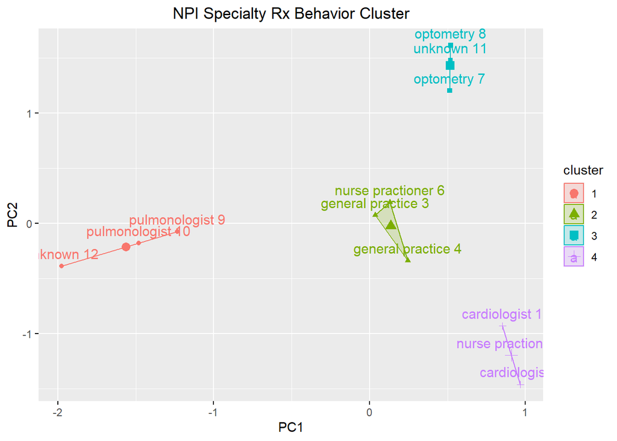

```r
#Visual the 2D graph with kmeans clustering
fviz_cluster(km, data = df) +
  ggtitle(label='NPI Specialty Rx Behavior Cluster') +
  theme(plot.title = element_text(hjust = 0.5))
```

# 6. Conclusion

Using PCA, we were able to visualize doctors’ prescription behavior in a 2D graph. Using k-means , we can cluster doctors with similar prescribing behavior together. This is super helpful when a doctor’s specialty is unknown or vague like nurse practitioner. For example: In the graph above, we can see that nurse practitioner 5 is clustered(purple) near the cardiologists. This means that nurse practitioner 5 must be involved with drugs related to the heart. If we were doing a campaign to promote a specialty drug related to the heart, we can assume that it is great to target this nurse practitioner 5. Without PCA and k-means, we wouldn’t be as confident to target a clinician with specialty title nurse practitioner because it is a vague title. Without PCA and k-means, it is still possible to understand doctors prescription behavior but this would require a person to manually check each doctors’ prescription and this could take a very long time.